# WayFindR: Displaying WikiPathways

Polina Bombina and Kevin R. Coombes

2026-09-25

# Introduction

One of the most challenging issues when converting biological pathways to graphs is also a major problem for graphs in general: what are the best ways to display the result? In the previous vignettes (Getting Started, and Metrics) we included default plots of the graphs, which leave something to be desired. Our initial constructions and plots use rectangles or circles (the only shapes available by default in `igraph`) of a fixed size, so the labels (such as gene names) often extend outside their containers. In addition, many edges cross and many nodes overlap, making it harder to visually identify the underlying topological structure of the graph that we learned from the pathway.

In this vignette, we want to look at methods that may help achieve better plots.

# Data Preparation

First, we load the required libraries:

```r
library(WayFindR)
suppressMessages( library(igraph) )
```

Now we are ready to load our GPML file and convert it into an igraph object:

```r
xmlfile <- system.file("pathways/WP3850.gpml", package = "WayFindR")
G <- GPMLtoIgraph(xmlfile)
class(G)
```

```
## [1] "igraph"
```

# Plots

First, we repeat the original plot of this pathway that we included in the “Getting Started” vignette (**Figure 1**).

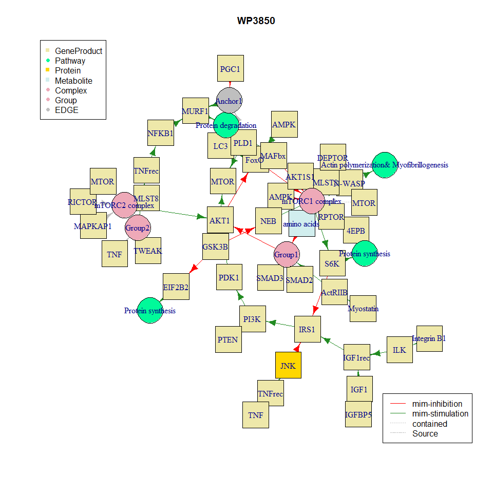

Figure 1: Circles and rectangles; layout with graphopt.

```r
set.seed(13579)
L <- igraph::layout_with_graphopt
plot(G, layout=L)
title("WP3850")
nodeLegend("topleft", G)
edgeLegend("bottomright", G)
```

Next, we change circles to ellipses, and try to find sensible sizes so the nodes can contain the labels (**Figure 2**). This helps with (mostly) fitting nodes to labels, but it doesn’t do anything about layout issues.

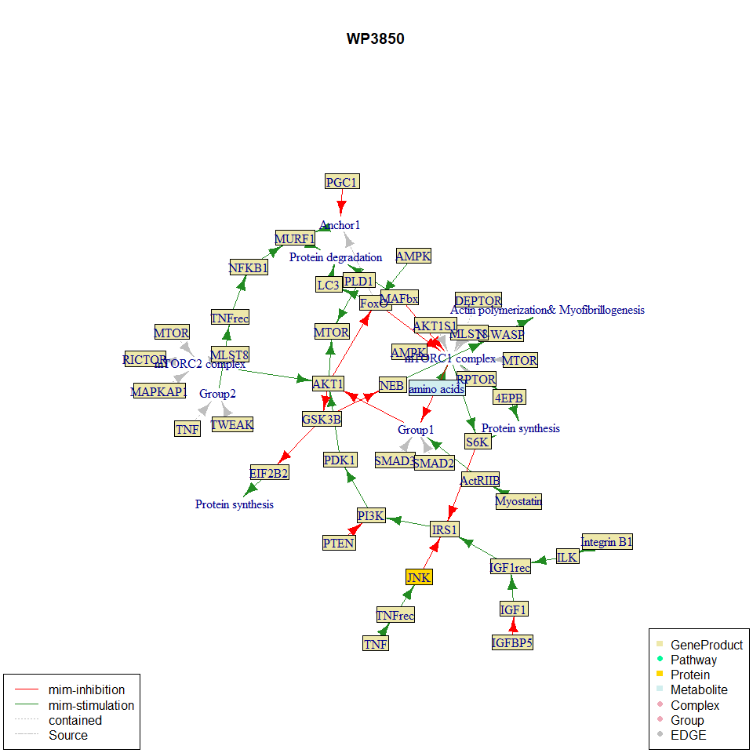

Figure 2: Resized ellipses.

```r
wc <- which(V(G)$shape == "circle")
G <- set_vertex_attr(G, "shape", index = wc, value = "ellipse")
plot(0,0, type = "n")
opar <- par(mai = c(0.05, 0.05, 1, 0.05))
sz <- (strwidth(V(G)$label) + strwidth("oo")) * 92
G <- set_vertex_attr(G, "size", value = sz)
G <- set_vertex_attr(G, "size2", value = strheight("I") * 2 * 92)
set.seed(13579)
L <- layout_with_graphopt(G)
plot(G, layout = L)
title("WP3850")
edgeLegend("bottomleft", G)
nodeLegend("bottomright", G)
```

```r
par(opar)
```

Now we use a different method to try to improve the layout (**Figure 3**). First, we compute coordinates from the `layout_nicely` algorithm, which mostly avoids edge-crossings when possibly, but doesn’t alleviate the issue with overlapping nodes. Then we pass those coordinates to one of the “force-directed” layout algorithms (in this case, Kamada-Kawai, but several other options are available). The second step reduces the overlap problem.

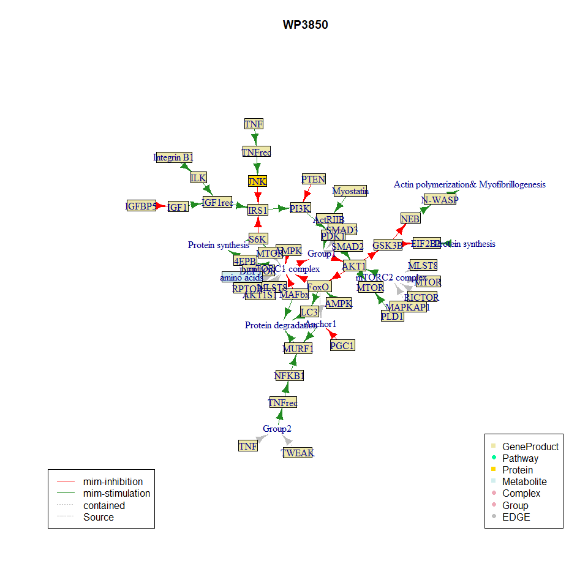

Figure 3: Two=step layout.

```r
set.seed(12345)
L <- layout_nicely(G)
L2 <- layout_with_kk(G, coords=L)
plot(G, layout = L2)
title("WP3850")
edgeLegend("bottomleft", G)
nodeLegend("bottomright", G)
```

```r
par(opar)
```

Finally, we switch R packages entirely. While `igraph` clearly has a much wider and more useful implementation of graph-theoretic algorithms from the computer science world, `Rgraphviz` has a better selection of node shapes and a different (though smaller) set of layout algorithms. We have wrapped umuch of the conversion from one format to another in our own “`as.graphNEL`” function. The result (**Figure 4**) clearly does a better job of fitting nodes to labels and avoiding overlaps, but it does have several edge crossings that are undesirable

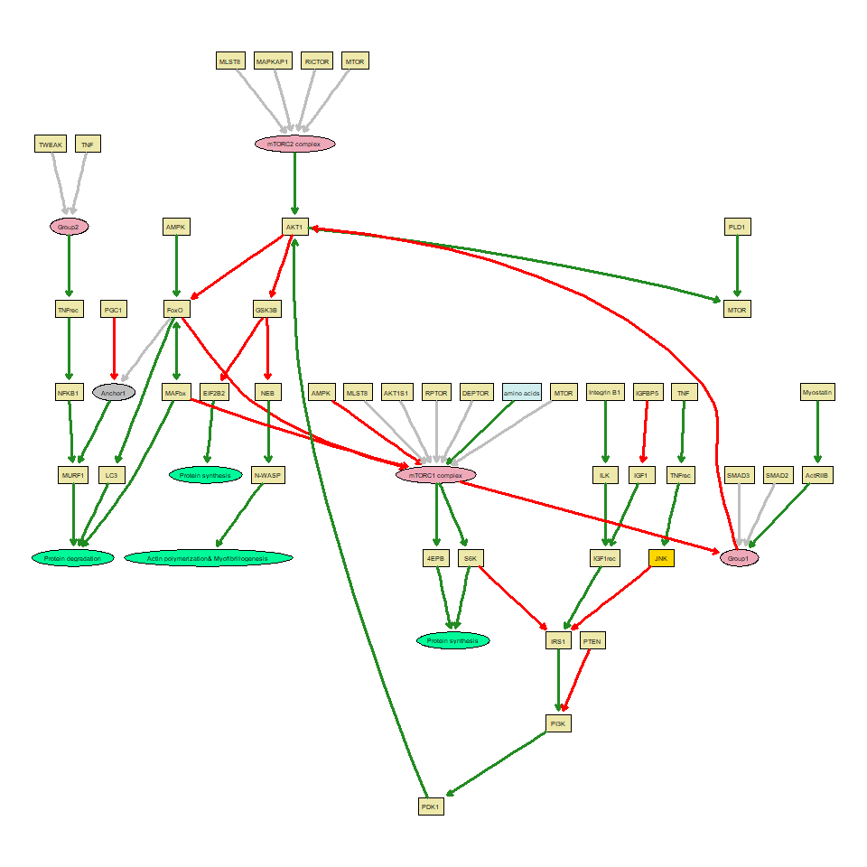

Figure 4: Plot after conversion ot graphNEL.

```r
GN <- as.graphNEL(G)
suppressMessages( library(Rgraphviz) )
plot(GN)
```

We can also explore different layout algorithms in Rgraphviz.

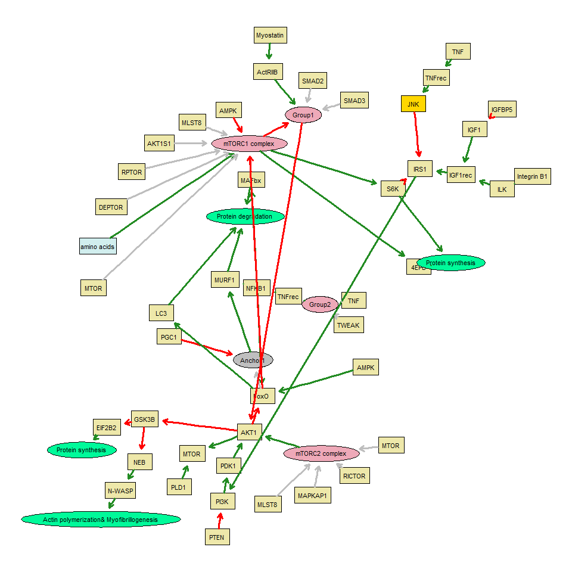

Figure 5: Rgraphviz plot with ‘twopi’ layout.

```r
plot(GN, "twopi")
```